# The R > E Phenomenon and the Distance-Difficulty Hypothesis: Modeling Response Time in Attitudinal Data

Authors

Affiliation

Nicole G. Bonge

University of Arkansas

Ronna C. Turner

University of Arkansas

Presentation Date

April 27, 2025

Abstract

Response time (or response latency) is a commonly used metric to assess item characteristics such as quality or comprehensibility, and respondent characteristics such as fatigue or effort. In this study, we apply response time models to attitudinal data, showing that survey item response time is related to a respondent’s latent trait level and item difficulty in relation to the respondent’s latent trait level (distance-difficulty hypothesis). We also investigate the R > E phenomenon, demonstrating that respondents take longer to refute items than to endorse them. Our results indicate that response time involves complex cognitive processes, and we caution researchers against using response time as a metric when assessing item or respondent characteristics (such as respondent effort or item quality) without controlling for other factors such as trait level, distance-difficulty item-person relationships, and item agreement. It is recommended that researchers conducting data quality assessments evaluate the occurrence of low data quality flagging for participants at different construct levels, to determine whether overidentification of participants in certain ability ranges may be related to item difficulty location.

Keywords

Response Time, Item Response Theory, Distance-Difficulty Hypothesis, F > C Phenomenon

## 1 Introduction

As computerized psychological testing has gained popularity over the past several decades, researchers are able to collect response time information alongside item responses at minimal cost. It is a widely held belief among survey researchers that response time is indicative of the cognitive effort required to answer an item (Höhne et al., 2017); thus, researchers point to response time to assess item quality and comprehensibility (Bassili et al., 1996; Lenzner, 2012; Lenzner et al., 2010). Researchers have also used response time to detect respondent fatigue (Nguyen, 2017), insufficient effort responding (Bowling et al., 2023; Krosnick, 1991; Ulitzsch et al., 2022), and other aberrant response patterns (van der Linden & van Krimpen-Stoop, 2003). Researchers have also used response time to investigate cognitive processes underlying item responses (De Boeck & Jeon, 2019).

In this study, we extend a set of models proposed by Tancoš et al. (2023) to attitudinal data and investigate how response time relates to several factors, including item difficulty, the strength of the latent trait of the respondent, and whether the respondent endorses the behavior described in the survey item. The models include an assessment of the distance-difficulty hypothesis (Lorenzo-Seva, 2007a; Thissen, 1983), which states that response time increases with decreasing person-item distance (that is, the distance between the respondent’s trait level and the item’s neutral threshold on the latent trait continuum). Moreover, we introduce the R > E phenomenon, an attitudinal analog to the “F > C phenomenon” seen in achievement contexts (Beckmann, 2000), where respondents take longer to provide incorrect answers than correct ones. The R > E phenomenon reflects our observation that respondents take longer to disagree with an attitudinal item than to agree with it. Finally, we investigate an interaction effect between the distance-difficulty hypothesis and the R > E phenomenon. Our study is designed to add to the body of literature regarding the complex processes involved in item responses and provides information about the use of response time when measuring item quality or respondent effort.

## 2 Theoretical Framework

### 2.1 The F > C Phenomenon

In the context of achievement testing, the F > C phenomenon (Beckmann, 2000), also called the I > C phenomenon, posits that false responses take longer to report than correct ones. Formally the F > C phenomenon is given by(Beckmann, 2000, as cited in Tancoš et al., 2023, p. 3):

$$t_{ij} = \mu + \gamma FC_{ij}+\epsilon_{ij},$$

where $t_{ij}$ is the response time of person $j$ on item $i$; $\mu$ is an intercept which describes the average time across each item and person; $FC_{ij}$ is a binary indicator of whether person $j$ answered item $i$ correctly; $\gamma$ is an unstandardized regression coefficient describing the mean difference in response time between false and correct answers; and $\epsilon_{ij}$ is a normally distributed residual. The F > C phenomenon has been demonstrated to be a significant predictor of response time in a number of prior studies for cognitive and achievement testing (e.g., Goldhammer et al., 2014; Goldhammer et al., 2015; Lasry et al., 2013; Preckel & Freund, 2005).

### 2.2 The Distance-Difficulty Hypothesis

Originally proposed by Thissen (1983) and later revised by Ferrando and Lorenzo-Seva (2007a), the distance difficulty hypothesis states that the response time for an item decreases as the distance between the respondent’s ability, or trait, level ($\theta_j$) and the item difficulty ($b_i$), given by $\delta_{ij}=|θ_j-b_i|$ increases. That is, a respondent should take more time to answer a question that is close to their trait level. On the other hand, a respondent should take less time to answer a question that is very easy or very difficult relative to their trait level. Thissen’s model (1983, p. 181) is given by:
$$\log{(t_{ij})} = \nu + s_i+u_j - bz_{ij}+\epsilon_{ij},$$
where $\log{(t_{ij})}$ is a logarithmic transformation of the response time for person $j$ on item $i$ (this transformation is meant to achieve normally distributed errors $\epsilon_{ij}$); $\nu$ is the intercept, representing the overall mean log response time; $s_i$ describes the average time respondent $i$ spent across all items; $u_j$ is the time required by a person of average ability to answer item $j$; and $b$ is the regression coefficient representing the relationship of response latency with respondent ability and item easiness (in $z_{ij}=a_j θ_i+c_j$, where $a_j$ is the discrimination of item $j$, $c_j$ is the easiness of item $j$, and $θ_i$ is the ability level of respondent $i$). Ferrando and Lorenzo-Seva (2007a, p. 528) proposed the following as an alternative person-item distance measure according to the two-parameter logistic (2PL) model:
$$\delta_{ij}=\sqrt{a_i^2 (θ_j-b_i )^2},$$
where $a_i$ is discrimination for item $i$. In well-designed items, $a_i$ is positive, and in this case, we can simplify the term to $\delta_{ij}=a_i|θ_j-b_i|$.

Heretofore, the models describing the distance-difficulty hypothesis have been designed for use with binary data. Ferrando and Lorenzo-Seva (2007b, p. 679) extended the distance-difficulty hypothesis to a model intended for use with graded or continuous items measuring a unidimensional construct, where the person-item distance is given by:
$$\delta_{ij}=\sqrt{(θ_i-τ_j)^2},$$
where $\tau_j$ is the “item threshold,” the point on the trait continuum, marking the point at which respondents are more likely to agree with an item than disagree with it. The distance-difficulty hypothesis was originally used with spatial ability (Thissen, 1983) but has also been extended to personality scales (e.g., Ferrando, 2006).

### 2.3 The Tancoš Models

Tancoš et al. (2023) proposed two sets of models relating to fluid intelligence in children: first, a model focused on the F > C phenomenon, which controls for item difficulty ($b_i$) and respondent ability ($\theta_j$) with an added interaction term of answer correctness ($FC_{ij}$) and respondent ability. This model is given by (Tancoš et al., 2023, p. 7):
$$\ln{(t_{ij})}=\mu+\nu_j+\beta_i+\gamma_1 FC_{ij}+\gamma_2 b_i+\gamma_3 \theta_j+\gamma_{13} FC_{ij}\theta_j+\epsilon_{ij},$$
where $\ln{t_{ij}}$ is a logarithmic transformation of the response time for person $j$ on item $i$; $\mu$ is the fixed intercept (representing the time spent by an average-ability respondent on an average-difficulty item); $\nu_j$ is the random intercept for each person (general speediness of respondent $j$; the average time respondent $j$ spent across all items); $\beta_i$ is the random intercept for each item (time required by a person of average ability to answer item $i$); $\gamma_1$, $\gamma_2$, $\gamma_3$, and $\gamma_{13}$ are the fixed effects of the corresponding predictors; and $\epsilon_{ij}$ is the normally distributed residual.

The second model Tancoš et al. (2023) proposed assesses the distance-difficulty hypothesis and investigates its incremental validity over the F > C phenomenon. This model is represented by (Tancoš et al., 2023, p. 8):
$$\ln{(t_{ij})}=\mu+\nu_j+\beta_i+\gamma_4 \delta_{ij}+\gamma_1 FC_{ij}+\gamma_{14} FC_{ij} \delta_{ij}+\epsilon_{ij},$$
where $\ln{(t_{ij})}$ is a logarithmic transformation of the response time for person $j$ on item $i$; $\mu$ is the fixed intercept; $\nu_j$ is the random intercept for each person; $\beta_i$ is the random intercept for each item; $\delta_{ij}=|\theta_j-b_i|$ is the absolute distance between respondent $j$’s ability level and item $i$’s difficulty; $FC_{ij}$ is a binary variable representing item correctness; $\gamma_1$, $\gamma_2$, $\gamma_3$, and $\gamma_{13}$ are the fixed effects of the corresponding predictors; and $\epsilon_{ij}$ is the normally distributed residual.

In their study, Tancoš et al. (2023) found that the F > C phenomenon remained significant after controlling for item difficulty and person ability, with an interaction between ability level and response correctness. Furthermore, ability level impacted response time (though only in items with moderate or high difficulty), but item difficulty did not influence response time. Taken together, the results indicated that on items with moderate-to-high difficulty, children with higher ability levels took longer to report incorrect answers than children with lower ability levels. However, Tancoš et al. (2023) found no relationship between ability level and response time with correct answers, challenging the ‘faster equals smarter’ stereotype.

Moreover, Tancoš et al. (2023) found incremental validity of the distance-difficulty hypothesis above and beyond the F > C phenomenon, providing support for the distance-difficulty hypothesis and its interaction with the F > C phenomenon. These results imply items that match a respondent’s ability level take the longest to answer, with increased time required for incorrectly answered items. Furthermore, as $\delta_{ij}$ increased, they found that the difference in response time narrows and eventually changes direction. That is, when an item is very easy or very difficult in relation to a respondent’s ability level, respondents take longer to report correct answers than false ones.

## 3 The Proposed Models

In this study, we adapt the Tancoš models to personality testing, using answer endorsement instead of answer correctness as an interaction term. Specifically, we test an attitudinal analog of the F > C phenomenon, postulating it takes respondents more time to refute, or disagree with, an item than endorse, or agree with, it. We call this version of the F > C phenomenon the ‘R > E phenomenon.’ This hypothesis is related to prior research on the F > C phenomenon (citation), and neuroscience research related to brain functioning during in-person interactions of agreement versus disagreement. For example, Hirsch et al. (2021) found that brain activity differed during interactions that included attitudinal agreement vs disagreement with lower levels of synchronous dyadic brain functioning during disagreement, potentially related to more complex cognitive load. If the R > E phenomenon holds, we will then investigate whether there is a significant interaction between the R > E phenomenon and the ability-difficulty distance (using an item’s neutral threshold in place of item difficulty as described by Ferrando and Lorenzo-Seva (2007a), since our data are polytomous and not binary). Such an interaction would suggest that there is a difference in the relationship between the time needed to respond to an item and the ability-difficulty distance among respondents who endorse the item and those who refute it.

## 4 Method

### 4.1 Participants and Measures

We examined data from the free online Machiavellianism scale (MACH-IV), developed by Christie and Geis (1970), from https://openpsychometrics.org/tests/MACH-IV. Before beginning the test, respondents agreed that their anonymous data could be used for research. Following the 20-item test, respondents were prompted with a 13-item survey containing general demographic questions. Each test question and survey question was presented on separate pages, with response time recorded as the amount of time, in milliseconds, spent per page. See Appendix 1 for MACH-IV item prompts.

Prior to testing the research questions, we conducted data quality analyses to select data that are less likely to be impacted by random or careless responding, which can decrease the accuracy of results (e.g., DeSimone & Harms, 2017; Huang et al., 2012). The dataset contained a vocabulary check as a direct data quality assessment in which respondents were prompted to indicate the words from a list of 16, of which they were sure they knew the definition. Three of the words were not real, so we removed responses where those words were selected. We also set aside respondents whose total test or survey time fell in the bottom or top decile, as an indirect data quality assessment. Our rationale for this choice is that respondents who fell in the bottom decile may not have spent sufficient time on the questions to provide reliable results (e.g., Reimers et al., 2023); whereas, respondents in the top decile of response time may not have completed the scale in a single sitting or without distraction. Third, we used the careless package in R (v1.2.2; Yentes & Wilhelm, 2023) to quantify longstring responses, the length of the maximum uninterrupted string of identical responses. We elected to remove responses with five or more identical consecutive responses, corresponding to the 95th percentile from this sample. Note, half of the items were reverse worded, with alternating placement used (see Appendix 1). For reference, the mean and median number of identical successive responses were 2.93 and 3.0, respectively.

Our final sample consisted of 11,772 adults, 48.9% female, who completed the scale in the United States and reported English was their native language. Only complete responses were considered. The average respondent age was 35.2 years, with reported ages ranging from 18 to 91 years.

### 4.2 Initial IRT Analysis

All analyses were conducted using R Statistical Software (v4.3.2; R Core Team, 2023). We began by performing an exploratory factor analysis (EFA) using the psych package in R (v2.4.3; Revelle, 2024) with all twenty items from the MACH-IV scale, reverse-coding negatively worded items before analysis. As the purpose of this study was to test the effects of question location (difficulty) and latent ability on response time and not on the interpretation of people’s level of Machiavellianism, we choose to set aside items that did not fit a one-factor model well. We did not want the results impacted by items measuring secondary nuisance factors rather than the variables being investigated. One item had insufficient factor loading (< .40). This item was set aside form the original 20, and we performed another EFA; an unweighted least squares estimation yielded sufficient factor loadings for a one-factor model. Given these results, we performed a unidimensional item response theory (IRT) analysis using the mirt R package (v1.41; Chalmers, 2012). Beginning with a comparison between the graded response model (GRM) and the generalized partial credit model (GPCM), model fit indices (AIC, BIC, SABIC, and log-likelihood) indicated that the GRM fit better than the GPCM (Table 1).

We proceeded with the GRM, extracting each item’s neutral threshold ($\tau_{i,N}$; the point on the latent trait continuum at which respondents are more likely to “agree” or “strongly agree” with an item than to be “neutral,” “disagree,” or “strongly disagree” with the item), discrimination ($a_i$), and each respondent’s estimated ability parameter ($\theta_j$). See Table 2 for item descriptive statistics and GRM parameters. Empirical reliability was high ($r_{\text{coefficient alpha}} = .91$).

### 4.3 Main Analysis

Our main analysis involved two sets of nested linear multilevel regression models. The first set of models tested the R > E phenomenon, controlling for item difficulty and respondent ability; the second set of models tested the distance-difficulty hypothesis and its interaction with the R > E phenomenon. We used the lme4 package (v1.1-35.3; Bates et al., 2015) to estimate each model, and after estimating, we computed the variance inflation factor (VIF) using the car package (v3.1-2; Fox & Weisberg, 2019) to check for multicollinearity. Finally, we used the lmerTest package (v3.1-3; Kuznetsova et al., 2017) to compare models.

First, we estimated a null model (Model 0) as a baseline for both sets of models. Consistent with Tancoš et al. (2023), Model 0 only included fixed and random intercept terms for respondents and items; all models used logarithmic transformation of response time for the dependent variable to linearize the relationship between the predictor variables and response time. We then defined the first series of models: Model A1 includes only a binary predictor for endorsement ($E_{ij}$); Model A2 includes two predictors, item neutral threshold ($\tau_{i,N}$) and respondent ability ($\theta_j$), as control variables; Model 3 includes the interaction term of answer endorsement and respondent ability to investigate the impact of respondent ability on the R > E phenomenon. Model A3 is as follows:

$$\ln{(t_{ij})}=\mu + \nu_j +\beta_i+\gamma_1E_{ij}+\gamma_2\tau_{i,N}+\gamma_3\theta_j +\gamma_{13}E_{ij}\theta_j+\epsilon_{ij},$$
where $E_{ij}$, $\tau_{i,N}$, and $\theta_j$ are defined above; $\mu$ is the fixed intercept representing the time spent by an average-ability respondent on an average-difficulty item; $\nu_j$ is the random intercept for each person (general speediness of respondent j; the average time respondent j spent across all items); $\beta_j$ is the random intercept for each item (time required by a person of average ability to answer item i); $\gamma_1$, $\gamma_2$, $\gamma_3$, and $\gamma_{13}$ are the fixed effects of the corresponding predictors; and $\epsilon_{ij}$ is the normally distributed residual. See Appendix 2 for a complete list of models tested.

The second set of models began with Model B1, testing the distance-difficulty hypothesis by including only the discrimination-adjusted absolute difference between the respondent ability and the neutral threshold for each item ($\delta_{ij}=a_i |θ_j-τ_{i,N} |$). Model B2 incorporates $E_{ij}$, a binary variable to represent the R > E phenomenon, to assess the incremental validity of the R > E phenomenon beyond the distance-difficulty hypothesis. Finally, Model B3 includes the interaction term of the distance $\delta_{ij}$ with answer endorsement ($E_{ij}$), to investigate whether the distance-difficulty effect follows a different pattern when respondents endorse an item or refute it. Model B3 is given by:
$$\ln{(t_{ij})}=\mu+\nu_j+\beta_i+\gamma_4 \delta_{ij}+\gamma_1 E_{ij}+\gamma_{14} E_{ij}\delta_{ij}+\epsilon_{ij},$$
where all variables are defined as stated above.

## 5 Results

### 5.1 Null Model

The null model, Model 0, provided a baseline for each set of models . The fixed intercept was significant ($μ=8.87$, 95% CI [8.73, 9.00]) and can be interpreted as the average response time of a respondent who is of average-ability on an average-difficulty item. Transforming the parameter from its logarithmic form and converting from milliseconds to seconds, we see the average response time was 7.12 seconds. Table 3 displays complete results for Model 0.

### 5.2 Models Assessing the R > E Phenomenon

In Model A2, the R > E phenomenon remained significant after controlling for item difficulty and respondent trait level ($γ_1=-0.04$, 95% CI [-0.04, -0.03]). Moreover, we found that respondents with higher levels of Machiavellianism took significantly less time to respond to questions than respondents with lower levels ($γ_3=-0.04$, 95% CI [-0.05, -0.04]). Moreover, response time was significantly related to the location of the item’s neutral threshold ($γ_2=0.19$, 95% CI [0.03, 0.35]). Table 5 displays complete results for Model A2.

In Model A3, the added interaction between endorsement and trait level was not significant ($γ_{13}=0.00$, 95% CI [-0.01,0.00]). Table 6 displays complete results for Model A3. Moreover, per the information criteria and goodness-of-fit measures, Model A3 did not fit the data better than the preceding model in the series (Table 7). Thus, we retain Model A2 as this series’ final model.

All effects combined, Model A2 indicates that respondents took significantly longer to refute items than to endorse them, regardless of trait level or the item’s neutral threshold. Further, respondents took longer to answer items with higher neutral thresholds, but response time decreased with increasing trait level, holding all other variables constant. Figure 1 reflects this pattern.

### 5.3 Models Assessing the Distance-Difficulty Hypothesis

In Model B1, we investigated the logarithm-transform of response time as a function of the ability-difficulty distance. The effect of the ability-difficulty distance was significant ($γ_4=-0.07$, 95% CI [-0.07, -0.06]). From this, we see the response time decreased by 6.8% with each logit unit increase of ability-difficulty distance. For example, the average response time was 7.71 seconds for respondents whose trait level matched the item’s neutral threshold (i.e., the discrimination-adjusted ability-difficulty difference was zero); response time decreases to 7.19 seconds when the ability-difficulty distance is one logit unit, and 6.70 seconds when the distance is two logit units. Table 8 displays complete results for Model B1.

## 6 Discussion

This study introduces the R > E Phenomenon, an attitudinal extension of the F > C phenomenon seen in achievement settings. In particular, we followed the Tancoš et al. (2023) methodology by investigating two phenomena: first, we assessed whether the R > E phenomenon was a significant predictor of response time after controlling for participants’ trait levels and item difficulties (operationalized in this context as an item’s neutral threshold). Our data show that, after controlling for trait level and item difficulty, respondents took longer to refute items than to endorse them. While the effect size is small, the R > E phenomenon accounts for significant variability in response time.

These findings may have multiple causes. Kowalski et al. (2018) found Machiavellianism is positively predicted by fluid intelligence, “the ability to be flexible and to respond adaptively to novel situations” (Gilhooly & Gilhooly, 2021, p. 186). A respondent with greater fluid intelligence may be able to assess whether, and how, an item applies to their life faster than someone with a lower level of fluid intelligence. Another explanation for the observed differences in response time between endorsing and rejecting an item could be that respondents who agree with an item can more quickly articulate applications of the item to their own lives. In contrast, respondents who do not endorse an item may think through a variety of situations in which the item may apply but ultimately does not. These results may also correspond with neuroscience research (e.g., Hirsch et al., 2021) that brain functioning for interactions related to agreement may be less complex than what is used for interactions where one disagrees.

Since the R > E phenomenon held after controlling for participant trait level and item difficulty, we investigated the distance-difficulty hypothesis and its interaction with the R > E phenomenon. We found evidence to support the distance-difficulty hypothesis in the context of an attitudinal survey, and a significant interaction between the distance-difficulty hypothesis and the R > E phenomenon. The most substantial impact was the decrease in response time with increasing distance between the respondent’s trait level and the item’s neutral threshold (that is, respondents answered faster to questions they more strongly agreed or disagreed with) and overall, the time used to answer the questions was consistently longer for those rejecting the questions rather than endorsing.

Response time is a metric often used to assess participants’ response effort and item characteristics including difficulty, exposure, interpretability, and suitability. Given the results of this study, we caution researchers against using response time alone to make such determinations. This study adds to the body of knowledge regarding the complexity of item response processes and challenges the practice of using response time in isolation to make determinations about respondent effort or item complexity and suitability.

## References

Bassili, J. N., & Scott, B. S. (1996). Response latency as a signal to question problems in survey research. *Public Opinion Quarterly*, *60*, 390–399. https://academic.oup.com/poq/article/60/3/390/1832313

Bates, D., Mächler, M., Bolker, B., & Walker, S. (2015). Fitting linear mixed-effects models using lme4. *Journal of Statistical Software*, *67*, 1–48. https://doi.org/10.18637/jss.v067.i01

Beckmann, J. F. (2000). Differentielle latenzzeitefekte bei der bearbeitung von reasoning-items. *Diagnostica*, *46*, 124–129.

Boeck, P. D., & Jeon, M. (2019). An overview of models for response times and processes in cognitive tests. *Frontiers in Psychology*, *10*. https://doi.org/10.3389/fpsyg.2019.00102

Bowling, N. A., Huang, J. L., Brower, C. K., & Bragg, C. B. (2023). The quick and the careless: The construct validity of page time as a measure of insufficient effort responding to surveys. *Organizational Research Methods*, *26*, 323–352. https://doi.org/10.1177/10944281211056520

Chalmers, R. P. (2012). Mirt: A multidimensional item response theory package for the r environment. *Journal of Statistical Software*, *48*, 1–29. https://doi.org/10.18637/jss.v048.i06

Christie, R., & Geis, F. L. (1970). *Studies in machiavellianism*. Elsevier. https://doi.org/10.1016/C2013-0-10497-7

DeSimone, J. A., & Harms, P. D. (2018). Dirty data: The effects of screening respondents who provide low-quality data in survey research. *Journal of Business and Psychology*, *33*, 559–577. https://doi.org/10.1007/s10869-017-9514-9

Ferrando, P. J. (2006). Person-item distance and response time: An empirical study in personality measurement. *Psicológica*, *27*, 137–148.

Ferrando, P. J., & Lorenzo-Seva, U. (2007). An item response theory model for incorporating response time data in binary personality items. In *Applied Psychological Measurement* (Vol. 31, pp. 525–543). https://doi.org/10.1177/0146621606295197

Fox, J., & Weisberg, S. (2019). *An r companion to applied regression* (Third). Sage.

Gilhooly, K. J., & Gilhooly, M. L. M. (2021). Aging effects on cognitive and noncognitive factors in creativity. In *Aging and creativity* (pp. 183–216). Elsevier. https://doi.org/10.1016/b978-0-12-816401-3.00008-1

Hirsch, J., Tiede, M., Zhang, X., Noah, J. A., Salama-Manteau, A., & Biriotti, M. (2021). Interpersonal agreement and disagreement during face-to-face dialogue: An fNIRS investigation. *Frontiers in Human Neuroscience*, *14*. https://doi.org/10.3389/fnhum.2020.606397

Höhne, J. K., Schlosser, S., & Krebs, D. (2017). Investigating cognitive effort and response quality of question formats in web surveys using paradata. *Field Methods*, *29*, 365–382. https://doi.org/10.1177/1525822X17710640

Huang, J. L., Curran, P. G., Keeney, J., Poposki, E. M., & DeShon, R. P. (2012). Detecting and deterring insufficient effort responding to surveys. *Journal of Business and Psychology*, *27*, 99–114. https://doi.org/10.1007/s10869-011-9231-8

Kowalski, C. M., Kwiatkowska, K., Kwiatkowska, M. M., Ponikiewska, K., Rogoza, R., & Schermer, J. A. (2018). The dark triad traits and intelligence: Machiavellians are bright, and narcissists and psychopaths are ordinary. *Personality and Individual Differences*, *135*, 1–6. https://doi.org/10.1016/j.paid.2018.06.049

Krosnick, J. A. (1991). Response strategies for coping with the cognitive demands of attitude measures in surveys. *Applied Cognitive Psychology*, *5*, 213–236. https://doi.org/10.1002/acp.2350050305

Kuznetsova, A., Brockhoff, P. B., & Christensen, R. H. B. (2017). lmerTest package: Tests in linear mixed effects models. *Journal of Statistical Software*, *82*, 1–26. https://doi.org/10.18637/jss.v082.i13

Lenzner, T. (2012). Effects of survey question comprehensibility on response quality. *Field Methods*, *24*, 409–428. https://doi.org/10.1177/1525822X12448166

Lenzner, T., Kaczmirek, L., & Lenzner, A. (2010). Cognitive burden of survey questions and response times: A psycholinguistic experiment. *Applied Cognitive Psychology*, *24*, 1003–1020. https://doi.org/10.1002/acp.1602

Nguyen, H. L. T. (2017). *Tired of survey fatigue? Insufficient effort responding due to survey fatigue* [PhD thesis]. Middle Tennessee State University.

Reimers, J., Turner, R. C., Tendeiro, J. N., Lo, W. J., & Keiffer, E. (2023). Performance of nonparametric person-fit statistics with unfolding versus dominance response models. *Measurement*, *21*, 232–253. https://doi.org/10.1080/15366367.2023.2165891

Revelle, W. (2024). *Psych: Procedures for psychological, psychometric, and personality research*. https://CRAN.R-project.org/package=psych

Tancoš, M., Chvojka, E., Jabůrek, M., & Portešová, Š. (2023). Faster ≠ smarter: Children with higher levels of ability take longer to give incorrect answers, especially when the task matches their ability. *Journal of Intelligence*, *11*. https://doi.org/10.3390/jintelligence11040063

Team, R. C. (2019). *R: A language and environment for statistical computing*. R Foundation for Statistical Computing. http://www.R-project.org/

Thissen, D. (1983). Timed testing- an approach using item response theory. In *New horizons in testing: Latent trait test theory and computerized adaptive testing* (pp. 179–203).

Ulitzsch, E., Pohl, S., Khorramdel, L., Kroehne, U., & Davier, M. von. (2022). A response-time-based latent response mixture model for identifying and modeling careless and insufficient effort responding in survey data. *Psychometrika*, *87*, 593–619. https://doi.org/10.1007/s11336-021-09817-7

Van Der Linden, W. J., & Van Krimpen-Stoop, E. M. L. A. (2003). Using response times to detect aberrant responses in computerized adaptive testing. In *PSYCHOMETRIKA* (Vol. 68, pp. 251–265).

Yentes, R., & Wilhelm, F. (2023). *Careless: Procedures for computing indices of careless responding*.

## Tables

Table 1. IRT Model Comparison

| Model | AIC | BIC | SABIC | Log-Likelihood |
| --- | --- | --- | --- | --- |
| GRM | 579,083.8 | 579,780.8 | 579,478.9 | -289,446.9 |
| GPCM | 583,294.6 | 583,991.5 | 583,689.6 | -291,552.3 |

Table 2. Descriptive Statistics for Items

| Item | Item Neutral Threshold | Item Discrimination | Response M | Response SD | Response Time (milliseconds) M | Response Time (milliseconds) SD |
| --- | --- | --- | --- | --- | --- | --- |
| 1 | 0.30 | 1.94 | 2.87 | 1.52 | 9,291.49 | 8,165.46 |
| 2 | 0.22 | 1.62 | 2.88 | 1.46 | 7,775.72 | 6,310.25 |
| 3R | 0.22 | 1.05 | 3.10 | 1.41 | 10,281.67 | 8,464.00 |
| 4R | 0.50 | 1.34 | 2.93 | 1.38 | 5,936.70 | 5,586.97 |
| 5 | -0.18 | 1.52 | 3.29 | 1.41 | 10,830.67 | 8,278.18 |
| 6R | -0.07 | 1.62 | 3.25 | 1.48 | 5,399.48 | 5,327.17 |
| 7R | -0.81 | 1.54 | 3.78 | 1.35 | 6,282.45 | 5,411.08 |
| 8 | 0.36 | 1.33 | 2.80 | 1.46 | 8,434.98 | 6,999.64 |
| 9R | 1.43 | 2.03 | 1.86 | 1.20 | 9,972.70 | 7,810.57 |
| 10R | 0.51 | 1.69 | 2.67 | 1.45 | 15,841.10 | 11,889.62 |
| 11R | -1.56 | 1.05 | 4.20 | 1.04 | 7,746.36 | 5,758.39 |
| 12 | -0.45 | 1.50 | 3.49 | 1.46 | 7,939.62 | 6,740.82 |
| 13 | 0.43 | 1.54 | 2.68 | 1.53 | 10,911.95 | 8,602.82 |
| 14R | -0.63 | 1.22 | 3.76 | 1.20 | 5,143.86 | 4,445.55 |
| 15 | -0.18 | 1.29 | 3.32 | 1.38 | 6,622.52 | 5,061.89 |
| 16R | -0.29 | 1.03 | 3.36 | 1.51 | 6,896.94 | 5,771.57 |
| 17R | -0.89 | 0.94 | 3.80 | 1.32 | 9,319.10 | 6,862.45 |
| 18 | -0.21 | 1.47 | 3.27 | 1.42 | 7,883.50 | 6,581.88 |
| 20 | 1.73 | 0.97 | 2.04 | 1.36 | 12,581.28 | 8,816.57 |

*Note.* Items ending in “R” were reverse coded before statistical analysis.

Table 3. Parameters for Model 0

|  | Coef. | Est. |  | 95% CI LL | 95% CI UL |
| --- | --- | --- | --- | --- | --- |
| *Fixed Effects* |  |  |  |  |  |
| Intercept | μ | 8.87 | *** | 8.73 | 9.00 |
| *Random Effects* |  |  |  |  |  |
| Person intercept variance | var(*ν<sub>j</sub>* ) | 0.05 | *** |  |  |
| Item intercept variance | var(*β<sub>i</sub>* ) | 0.09 | *** |  |  |
| Residual Variance | var(*ε<sub>ij</sub>* ) | 0.24 |  |  |  |

*Note.* Coef – coefficient; Est – estimate; CI – confidence interval; LL – lower limit; UL – upper limit; Var – variance. * p < .05, ** p < .01, *** p < .001.

Table 4. Parameters for Model A1

|  | Coef. | Est. |  | 95% CI LL | 95% CI UL |
| --- | --- | --- | --- | --- | --- |
| *Fixed Effects* |  |  |  |  |  |
| Intercept | μ | 8.88 | *** | 8.74 | 9.02 |
| Endorse | γ<sub>1</sub> | -0.04 | *** | -0.04 | -0.03 |
| *Random Effects* |  |  |  |  |  |
| Person intercept variance | var(*ν<sub>j</sub>* ) | 0.05 | *** |  |  |
| Item intercept variance | var(*β<sub>i</sub>* ) | 0.09 | *** |  |  |
| Residual Variance | var(*ε<sub>ij</sub>* ) | 0.24 |  |  |  |

*Note.* Coef – coefficient; Est – estimate; CI – confidence interval; LL – lower limit; UL – upper limit; Var – variance. * p < .05, ** p < .01, *** p < .001.

Table 5. Parameters for Model A2

|  | Coef. | Est. |  | 95% CI LL | 95% CI UL |
| --- | --- | --- | --- | --- | --- |
| *Fixed Effects* |  |  |  |  |  |
| Intercept | μ | 8.88 | *** | 8.76 | 9.00 |
| Endorse | γ<sub>1</sub> | -0.04 | *** | -0.04 | -0.03 |
| Item Neutral Threshold | γ<sub>2</sub> | 0.19 | * | 0.03 | 0.35 |
| Person Trait Level | γ<sub>3</sub> | -0.04 | *** | -0.05 | -0.04 |
| *Random Effects* |  |  |  |  |  |
| Person intercept variance | var(*ν<sub>j</sub>* ) | 0.05 | *** |  |  |
| Item intercept variance | var(*β<sub>i</sub>* ) | 0.07 | *** |  |  |
| Residual Variance | var(*ε<sub>ij</sub>* ) | 0.24 |  |  |  |

*Note.* Coef – coefficient; Est – estimate; CI – confidence interval; LL – lower limit; UL – upper limit; Var – variance. * p < .05, ** p < .01, *** p < .001.

Table 6. Parameters for Model A3

|  | Coef. | Est. |  | 95% CI LL | 95% CI UL |
| --- | --- | --- | --- | --- | --- |
| *Fixed Effects* |  |  |  |  |  |
| Intercept | μ | 8.88 | *** | 8.76 | 9.00 |
| Endorse | γ<sub>1</sub> | -0.04 | *** | -0.04 | -0.03 |
| Item Neutral Threshold | γ<sub>2</sub> | 0.19 | * | 0.02 | 0.35 |
| Person Trait Level | γ<sub>3</sub> | -0.04 | *** | -0.05 | -0.04 |
| Endorse x Trait Level | γ<sub>13</sub> | 0.00 |  | -0.01 | 0.00 |
| *Random Effects* |  |  |  |  |  |
| Person intercept variance | var(*ν<sub>j</sub>* ) | 0.05 | *** |  |  |
| Item intercept variance | var(*β<sub>i</sub>* ) | 0.07 | *** |  |  |
| Residual Variance | var(*ε<sub>ij</sub>* ) | 0.24 |  |  |  |

*Note.* Coef – coefficient; Est – estimate; CI – confidence interval; LL – lower limit; UL – upper limit; Var – variance. * p < .05, ** p < .01, *** p < .001.

Table 7. Model Fit For Series 1 Models

|  | Model 0 | Model A1 | Model A2 | Model A3 |
| --- | --- | --- | --- | --- |
| Conditional *R<sup>2</sup>* | .36 | .37 | .37 | .37 |
| Marginal *R<sup>2</sup>* | .00 | .00 | .06 | .06 |
| Log-likelihood | -159,795.6 | -159,668.0 | -159,497.3 | -159,497.3 |
| AIC | 319,599.1 | 319,345.9 | 319,008.7 | 319,010.7 |
| BIC | 319,640.2 | 319,397.3 | 319,080.7 | 319,092.9 |
| Δχ<sup>2</sup>(df) |  | 255.2(1)*** | 341.2(2)*** | 0.02(1) |

Table 8. Parameters for Model B1

|  | Coef. | Est. |  | 95% CI LL | 95% CI UL |
| --- | --- | --- | --- | --- | --- |
| *Fixed Effects* |  |  |  |  |  |
| Intercept | μ | 8.95 | *** | 8.81 | 9.09 |
| Ability-Diffiulty Distance | γ<sub>4</sub> | -0.07 | *** | -0.07 | -0.06 |
| *Random Effects* |  |  |  |  |  |
| Person intercept variance | var(*ν<sub>j</sub>* ) | 0.05 | *** |  |  |
| Item intercept variance | var(*β<sub>i</sub>* ) | 0.09 | *** |  |  |
| Residual Variance | var(*ε<sub>ij</sub>* ) | 0.23 |  |  |  |

*Note.* Coef – coefficient; Est – estimate; CI – confidence interval; LL – lower limit; UL – upper limit; Var – variance. * p < .05, ** p < .01, *** p < .001.

Table 9. Parameters for Model B2

|  | Coef. | Est. |  | 95% CI LL | 95% CI UL |
| --- | --- | --- | --- | --- | --- |
| *Fixed Effects* |  |  |  |  |  |
| Intercept | μ | 8.97 | *** | 8.82 | 9.11 |
| Endorse | γ<sub>1</sub> | -0.04 | *** | -0.04 | -0.03 |
| Person-Item Distance | γ<sub>4</sub> | -0.09 | *** | -0.11 | -0.08 |
| *Random Effects* |  |  |  |  |  |
| Person intercept variance | var(*ν<sub>j</sub>* ) | 0.05 | *** |  |  |
| Item intercept variance | var(*β<sub>i</sub>* ) | 0.09 | *** |  |  |
| Residual Variance | var(*ε<sub>ij</sub>* ) | 0.23 |  |  |  |

*Note.* Coef – coefficient; Est – estimate; CI – confidence interval; LL – lower limit; UL – upper limit; Var – variance. * p < .05, ** p < .01, *** p < .001.

Table 10. Parameters for Model B3

|  | Coef. | Est. |  | 95% CI LL | 95% CI UL |
| --- | --- | --- | --- | --- | --- |
| *Fixed Effects* |  |  |  |  |  |
| Intercept | μ | 8.96 | *** | 8.82 | 9.10 |
| Endorse | γ<sub>1</sub> | -0.03 | *** | -0.03 | -0.02 |
| Ability-Diffiulty Distance | γ<sub>4</sub> | -0.06 | *** | -0.06 | -0.06 |
| Endorse x Distance | γ<sub>14</sub> | -0.01 | ** | -0.01 | -0.00 |
| *Random Effects* |  |  |  |  |  |
| Person intercept variance | var(*ν<sub>j</sub>* ) | 0.05 | *** |  |  |
| Item intercept variance | var(*β<sub>i</sub>* ) | 0.09 | *** |  |  |
| Residual Variance | var(*ε<sub>ij</sub>* ) | 0.23 |  |  |  |

*Note.* Coef – coefficient; Est – estimate; CI – confidence interval; LL – lower limit; UL – upper limit; Var – variance. * p < .05, ** p < .01, *** p < .001.

Table 11. Model Fit For Series 2 Models

|  | Model 0 | Model B1 | Model B2 | Model B3 |
| --- | --- | --- | --- | --- |
| Conditional *R<sup>2</sup>* | .36 | .39 | .39 | .39 |
| Marginal *R<sup>2</sup>* | .00 | .01 | .01 | .01 |
| Log-likelihood | -159,795.6 | -158,609.8 | -158,495.8 | -158,490.3 |
| AIC | 319,599.1 | 317,229.7 | 317,003.6 | 316,994.6 |
| BIC | 319,640.2 | 317,281.1 | 317,065.3 | 317,066.6 |
| Δχ<sup>2</sup>(df) |  | 2,371.45(1)*** | 228.09(1)*** | 10.94(1)*** |

## Figures

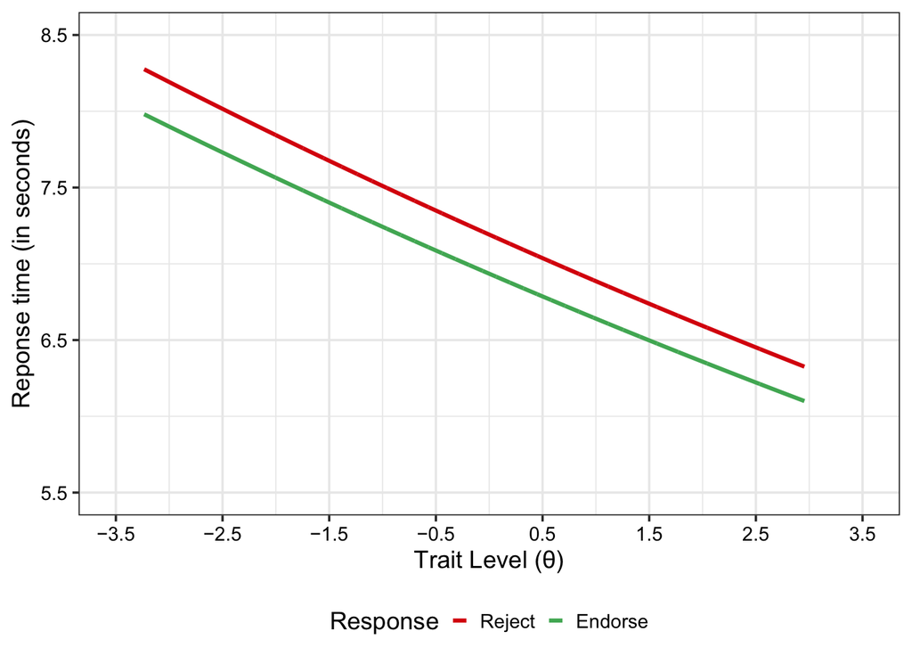

Figure 1. From Model A3, predicted response times according to respondent’s trait level and whether the respondent rejected the item (red) or endorsed it (green).

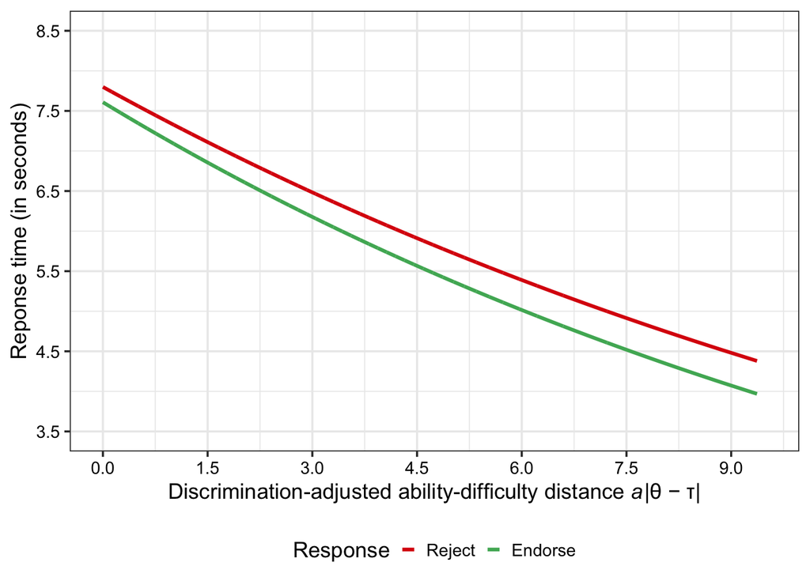

Figure 2. From Model B3, predicted response times according to the discrimination-adjusted distance between the respondent’s trait level and the item’s neutral threshold (“ability-difficulty distance”), by whether the respondent rejected the item (red) or endorsed it (green).

## Appendix

### Appendix 1. MACH-IV Scale Items

[output not shown]

*Note.* Items ending in * were dropped due to insufficient factor loadings. Reprinted from Christie and Geis (1970).

### Appendix 2. List of Models Used

Null Model (Model 0):

$$\ln{(t_{ij})} = \mu + \nu_j + \beta_i + \epsilon_{ij}$$

Model A1:

$$\ln{(t_{ij})} = \mu + \nu_j + \beta_i + \gamma_1 E_{ij} + \epsilon_{ij}$$

Model A2:

$$\ln{(t_{ij})} = \mu + \nu_j + \beta_i + \gamma_1 E_{ij} + \gamma_2\tau_{i,N} + \gamma_3 \theta_j + \epsilon_{ij}$$

Model A3:

$$\ln{(t_{ij})} = \mu + \nu_j + \beta_i + \gamma_1 E_{ij} + \gamma_2\tau_{i,N} + \gamma_3 \theta_j + \gamma_{13} E_{ij} \theta_j+ \epsilon_{ij}$$

Model B1:

$$\begin{align}
\ln{(t_{ij})} &= \mu + \nu_j + \beta_i + \gamma_4 a_i |\theta_j - \tau_{i,N}|+ \epsilon_{ij} \\
&=\mu + \nu_j +\beta_i +\gamma_4\delta_{ij}+\epsilon_{ij}
\end{align}$$

Model B2:

$$\begin{align}
\ln{(t_{ij})} &= \mu + \nu_j + \beta_i + \gamma_4 a_i |\theta_j - \tau_{i,N}|+ \gamma_1E_{ij}+\epsilon_{ij} \\
&=\mu + \nu_j +\beta_i +\gamma_4\delta_{ij}+\gamma_1 E_{ij}+\epsilon_{ij}
\end{align}$$

Model B3:

$$\begin{align}
\ln{(t_{ij})} &= \mu + \nu_j + \beta_i + \gamma_4 a_i |\theta_j - \tau_{i,N}|+ \gamma_1E_{ij}+\gamma_{14}E_{ij}a_i|\theta_j-\tau_{i,N}|+\epsilon_{ij} \\
&=\mu + \nu_j +\beta_i +\gamma_4\delta_{ij}+\gamma_1 E_{ij}+\gamma_{14}E_{ij}\delta_{ij}+\epsilon_{ij}
\end{align}$$